# Overview and QC filtering

CSF_01

Paula Nieto

Centro Nacional de Análisis Genómico (CNAG)  
paula.nieto@cnag.crg.eu

September 21, 2023

```
## All parameters passed to render this file:
```

```
## proj_dir: /scratch/devel/pnieto/projects/CSF/data/CSF_01
## proj_name: CSF_01
## out_dir: /scratch/devel/pnieto/projects/CSF/data/CSF_01/output/01_QC_filtering
## min_lib_size: 800
## max_lib_size: 25000
## min_n_genes: 350
## max_n_genes: 6000
## max_pct_mt: 20
```

# CSF_01

- *nFeature_RNA* is the number of genes expressed in each cell
- *nCount_RNA* is the total number of RNA molecules detected in a cell (number of UMIs)
- *percent.mt* is the percentage of expressed RNA that corresponds to mitochondrial genes
- *doublet_score* is the score that a cell might be a doublet, instead of a single cell

Low number of genes or RNA molecules for a cell indicates that it may be dead or an empty droplet. On the contrary, cells with high number of genes or molecules indicate that the “cell” may in fact be a doublet (or multiplet). Cells with high mitochondrial content may also be dead or broken cells as the mitochondrial material is the last to degrade.

By removing outliers from these groups we expect to remove most bad quality cells from the downstream analysis.

## General QC visualization

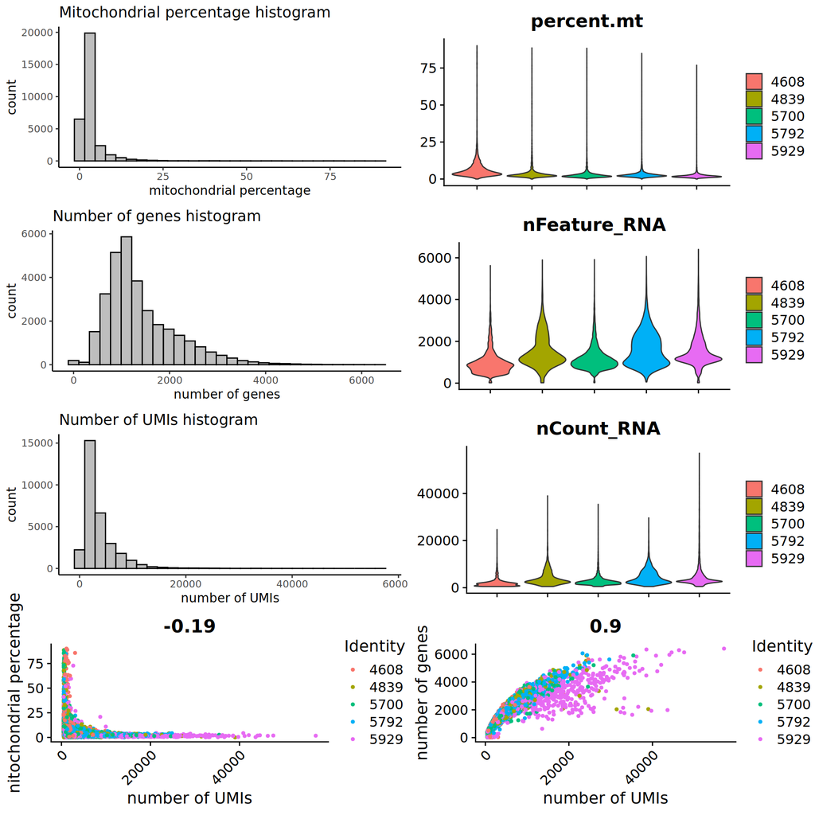

## Library Size

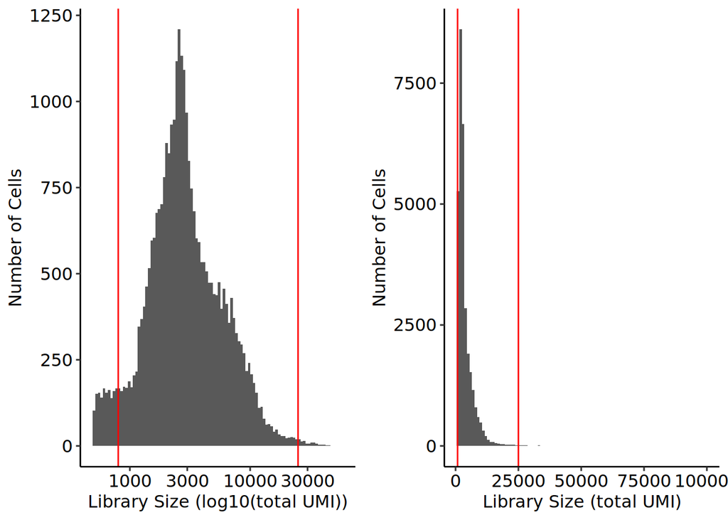

## Number of detected genes

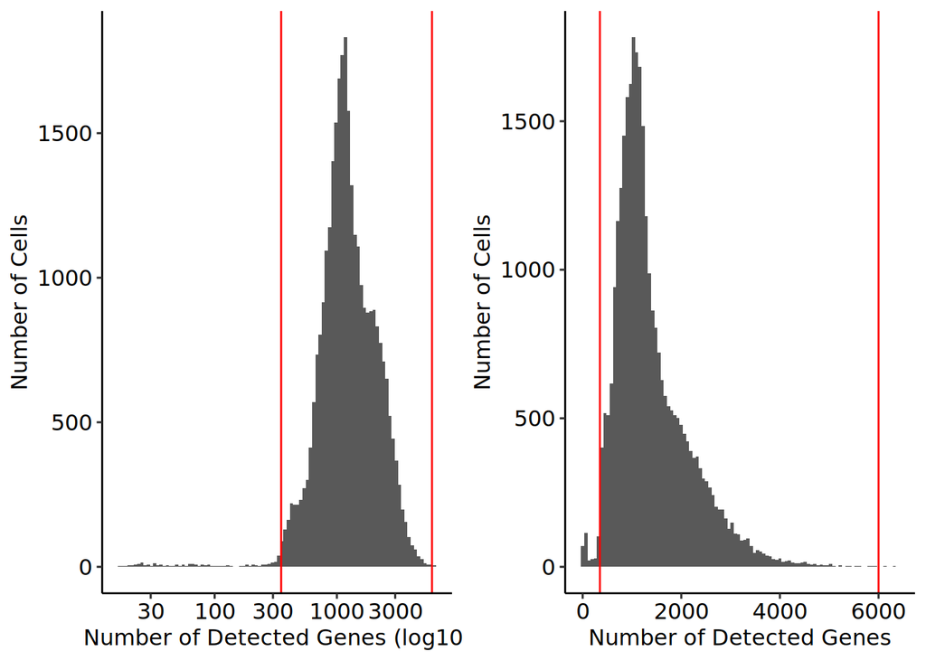

Number of detected genes across samples:

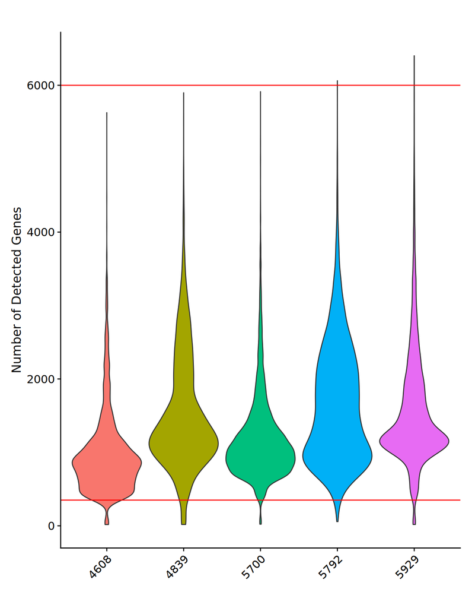

## Fraction of mitochondrial content

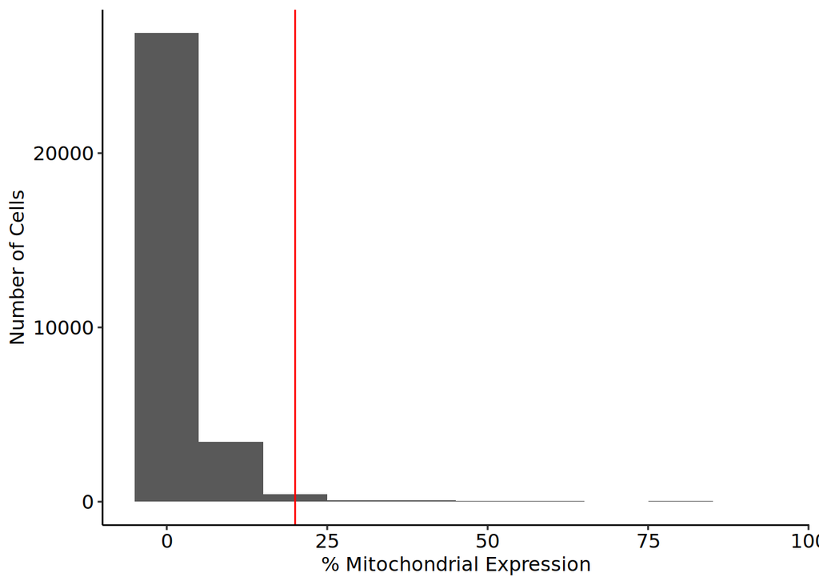

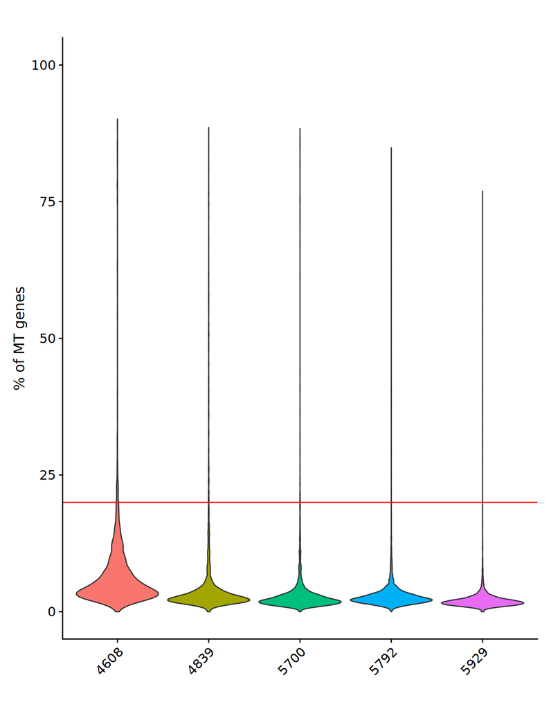

## Joint QC metrics

It is important to assess how these variables covary, since metabolically active cells might also have a high mitochondrial expression:

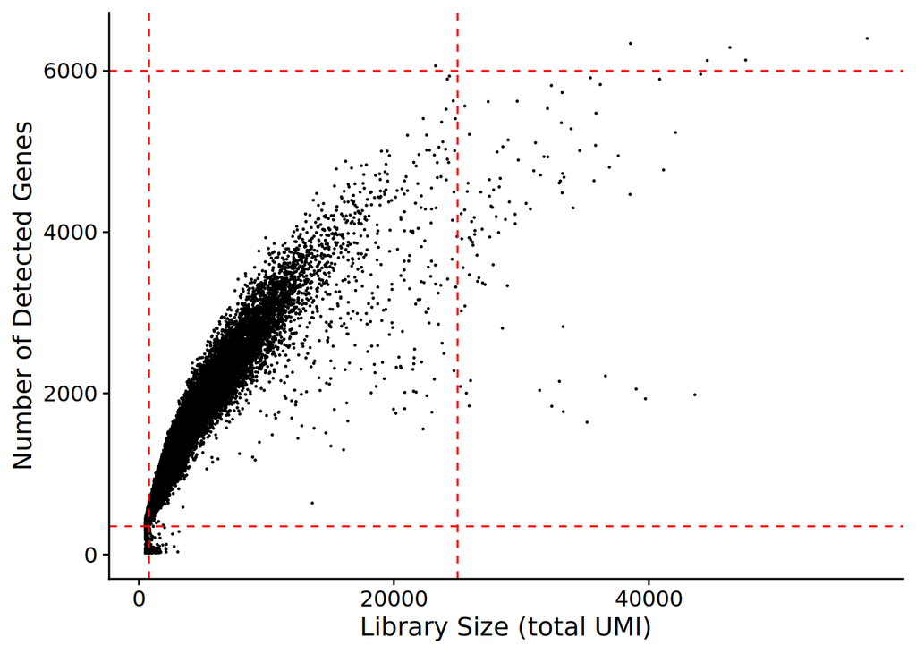

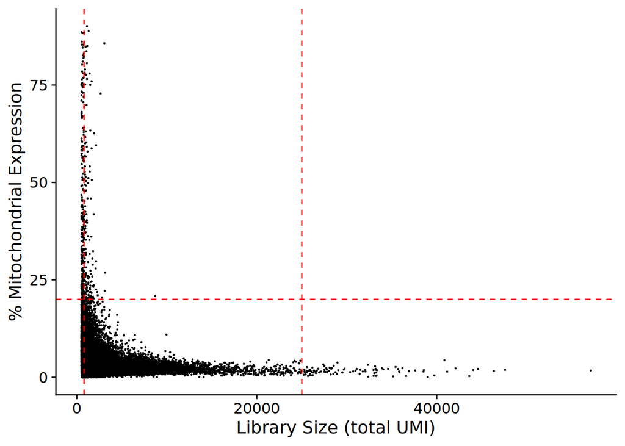

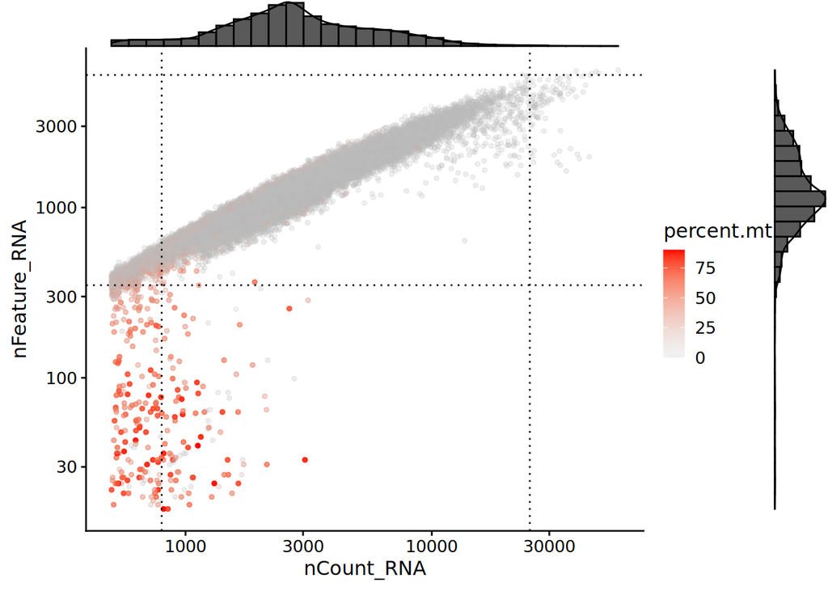

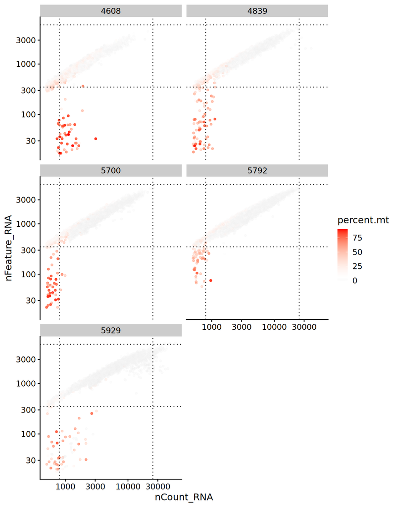

## Scrublet

We run [scrublet](https://www.sciencedirect.com/science/article/pii/S2405471218304745) on each of the samples but for the moment we are not going to filter out any cells based on doublet score.

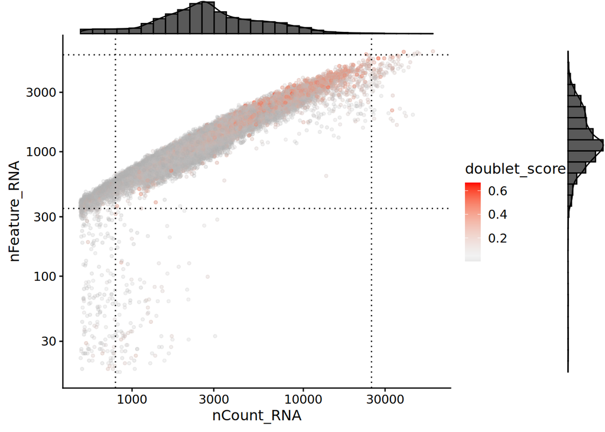

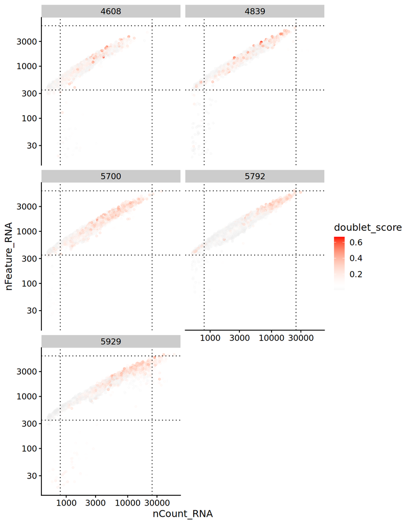

## Filtering

- between 800 and 25000 UMIs per cell
- between 350 and 6000 genes
- less than 20% mitochondrial content

How many cells are we keeping?

```
##
## FALSE  TRUE
##  1828 29213
```

## QC summary table

Comparison before and after filtering

| sample | num_cells_before_qc | num_cells_after_qc | average_library_size | average_num_detected_genes | average_mitochondrial_fraction |
| --- | --- | --- | --- | --- | --- |
| 4608 | 3,984 | 3,238 | 2,351.320 | 1,101.183 | 5.112959 |
| 4839 | 3,504 | 3,305 | 4,241.574 | 1,597.409 | 3.272739 |
| 5700 | 8,989 | 8,616 | 2,927.454 | 1,216.784 | 2.598649 |
| 5792 | 7,602 | 7,428 | 4,677.854 | 1,679.712 | 2.822810 |
| 5929 | 6,962 | 6,626 | 4,477.924 | 1,578.308 | 1.990053 |

Back to top

Back to top